# Soja Fase 3

AgriPredict+

Octavio Deliberato Neto

19/05/2019

## 1. Introdução

Partindo do modelo melhorado de soja construído em `Soja Fase 2.Rmd`, tentaremos melhorar o desempenho do modelo de regressão (R<sup>2</sup>) com os dados de solo enviados pela FMS.

O primeiro trabalho a ser feito, então, é preparar os dados de solo para que sejam incorporados ao *dataset* construído em `Soja Fase 2.Rmd`, e então passar à etapa de modelagem matemática.

## 2. Preparação dos dados

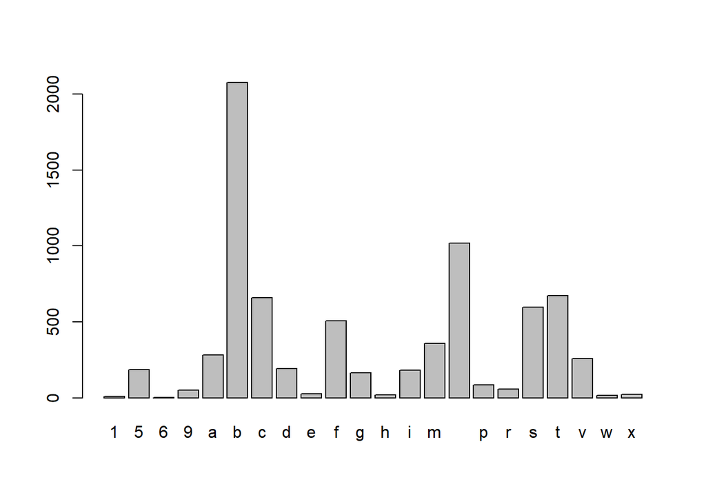

```r
# Antes de mais nada, leio e preparo os dados de soja da Fase 2
soja_df <- read.csv("soja_df.csv", encoding = "UTF-8")
soja_df$material <- substr(soja_df$material, 1, 1) # try to balance things out
barplot(table(soja_df$material)) # still not balanced, but let's give it a shot
```

```r
soja_df$material <- soja_df$material %>% factor()
soja_df <- soja_df %>% mutate_at(vars(matches("rain_")), factor)
soja_df %>% glimpse()
```

```
Observations: 7,445
Variables: 17
$ material       <fct> f, n, b, b, f, b, n, b, v, b, n, c, c, b, c, b,...
$ site           <fct> antôniojoão, antôniojoão, antôniojoão, antônioj...
$ ciclo          <dbl> 104.0, 109.0, 112.0, 107.0, 112.0, 114.0, 115.0...
$ safra          <fct> 2008-2009, 2008-2009, 2008-2009, 2008-2009, 200...
$ epoca          <fct> 2, 2, 2, 2, 2, 2, 2, 2, 2, 2, 2, 2, 2, 2, 2, 2,...
$ rain_q1.low    <fct> 0, 0, 0, 0, 0, 0, 0, 0, 0, 0, 0, 0, 0, 0, 0, 0,...
$ rain_q1.med    <fct> 0, 0, 0, 0, 0, 0, 0, 0, 0, 0, 0, 0, 0, 0, 0, 0,...
$ rain_q1.high   <fct> 0, 0, 0, 0, 0, 0, 0, 0, 0, 0, 0, 0, 0, 0, 0, 0,...
$ rain_q2.norain <fct> 0, 0, 0, 0, 0, 0, 0, 0, 0, 0, 0, 0, 0, 0, 0, 0,...
$ rain_q2.low    <fct> 0, 0, 0, 0, 0, 0, 0, 0, 0, 0, 0, 0, 0, 0, 0, 0,...
$ rain_q2.med    <fct> 0, 0, 0, 0, 0, 0, 0, 0, 0, 0, 0, 0, 0, 0, 0, 0,...
$ rain_q3.norain <fct> 0, 0, 0, 0, 0, 0, 0, 0, 0, 0, 0, 0, 0, 0, 0, 0,...
$ rain_q3.low    <fct> 0, 0, 0, 0, 0, 0, 0, 0, 0, 0, 0, 0, 0, 0, 0, 0,...
$ rain_q4.low    <fct> 0, 0, 0, 0, 0, 0, 0, 0, 0, 0, 0, 0, 0, 0, 0, 0,...
$ rain_q4.med    <fct> 1, 1, 1, 1, 1, 1, 1, 1, 1, 1, 1, 1, 1, 1, 1, 1,...
$ rain_q4.high   <fct> 0, 0, 0, 0, 0, 0, 0, 0, 0, 0, 0, 0, 0, 0, 0, 0,...
$ productivity   <dbl> 66.0, 65.0, 63.6, 63.5, 59.9, 58.4, 57.8, 57.3,...
```

```r
# Agora, vem a etapa de dataprep dos dados de solo enviados pela FMS
solo_soja <- read_excel("data-raw-2/solo_fms.xlsx", na = "-")
solo_soja$SATPOR_K <- as.numeric(solo_soja$SATPOR_K)
solo_soja <- solo_soja %>% filter(Cultura == "Soja")
solo_soja$Safra <- solo_soja$Safra %>%
  str_replace_all(pattern = "/", replacement = "-")
solo_soja$Local <- solo_soja$Local %>%
  str_replace_all("[^[:alnum:]]", "")
solo_soja$Local <- solo_soja$Local %>%
  str_replace_all("[[:punct:]]", "")
solo_soja$Local <- solo_soja$Local %>% tolower()
solo_soja$Cultura <- NULL # sei que é somente soja
solo_soja <- solo_soja %>% rename(site = Local,
                                  safra = Safra,
                                  depth = Profundidade)
names(solo_soja)[13] <- "H_Al_CMOLCDM3"
names(solo_soja)[29] <- "ARGILA"
summary(solo_soja)
```

```
     site              safra              depth              PH_CACL2
 Length:162         Length:162         Length:162         Min.   :4.100
 Class :character   Class :character   Class :character   1st Qu.:4.760
 Mode  :character   Mode  :character   Mode  :character   Median :5.100
                                                          Mean   :5.083
                                                          3rd Qu.:5.300
                                                          Max.   :6.500
                                                          NA's   :6
    PH_AGUA         MO_GDM3       P_meh_MG_DM3     P_res_MG_DM3
 Min.   :4.800   Min.   : 2.00   Min.   : 0.400   Min.   : 3.80
 1st Qu.:5.410   1st Qu.:20.20   1st Qu.: 1.800   1st Qu.:10.46
 Median :5.720   Median :26.86   Median : 6.395   Median :32.76
 Mean   :5.716   Mean   :26.67   Mean   : 9.893   Mean   :29.98
 3rd Qu.:5.995   3rd Qu.:33.95   3rd Qu.:14.970   3rd Qu.:52.88
 Max.   :6.880   Max.   :49.80   Max.   :44.450   Max.   :52.88
 NA's   :24      NA's   :11      NA's   :6        NA's   :147
    K_MG_DM3       CA_CMOLCDM3      MG_CMOLCDM3       AL_CMOLCDM3
 Min.   :0.0100   Min.   : 0.300   Min.   : 0.0500   Min.   :0.0000
 1st Qu.:0.1000   1st Qu.: 2.300   1st Qu.: 0.9075   1st Qu.:0.0000
 Median :0.1800   Median : 3.750   Median : 1.2000   Median :0.0000
 Mean   :0.2707   Mean   : 3.985   Mean   : 1.5797   Mean   :0.2328
 3rd Qu.:0.3425   3rd Qu.: 5.300   3rd Qu.: 1.6000   3rd Qu.:0.1575
 Max.   :2.8000   Max.   :13.000   Max.   :24.0000   Max.   :6.3400
 NA's   :6        NA's   :8        NA's   :8         NA's   :6
 H_Al_CMOLCDM3      SOM_BASES           CTC           SAT_BASES
 Min.   : 1.400   Min.   : 0.600   Min.   :  2.40   Min.   :15.40
 1st Qu.: 3.100   1st Qu.: 3.255   1st Qu.:  7.22   1st Qu.:43.53
 Median : 4.290   Median : 4.910   Median :  9.90   Median :53.55
 Mean   : 4.748   Mean   : 6.319   Mean   : 11.12   Mean   :53.26
 3rd Qu.: 5.625   3rd Qu.: 7.530   3rd Qu.: 12.14   3rd Qu.:66.15
 Max.   :20.000   Max.   :86.000   Max.   :106.00   Max.   :81.00
 NA's   :10       NA's   :8        NA's   :8        NA's   :6
    S_MG_DM3         ZN_MG_DM3          B_MG_DM3        CU_MG_DM3
 Min.   :  1.000   Min.   :  0.190   Min.   :0.0900   Min.   : 0.060
 1st Qu.:  7.303   1st Qu.:  1.225   1st Qu.:0.2200   1st Qu.: 1.170
 Median : 11.045   Median :  1.900   Median :0.2900   Median : 5.800
 Mean   : 24.079   Mean   :  4.947   Mean   :0.3205   Mean   : 5.769
 3rd Qu.: 31.887   3rd Qu.:  3.800   3rd Qu.:0.4175   3rd Qu.: 8.900
 Max.   :124.900   Max.   :234.890   Max.   :0.8000   Max.   :18.520
 NA's   :26        NA's   :55        NA's   :60       NA's   :55
```

[output cut: 9 more lines]

```
 Min.   : 9.30   Min.   : 2.70   Min.   : 0.00   Min.   : 0.000
 1st Qu.:28.27   1st Qu.: 9.20   1st Qu.:39.73   1st Qu.: 0.000
 Median :35.38   Median :11.20   Median :49.16   Median : 0.000
 Mean   :36.92   Mean   :11.41   Mean   :47.70   Mean   : 3.642
 3rd Qu.:47.19   3rd Qu.:12.65   3rd Qu.:55.90   3rd Qu.: 2.800
 Max.   :66.59   Max.   :21.92   Max.   :78.00   Max.   :61.670
 NA's   :59      NA's   :59      NA's   :70      NA's   :73
     ARGILA
 Min.   :11.90
 1st Qu.:36.25
 Median :50.00
 Mean   :45.43
 3rd Qu.:55.42
 Max.   :70.00
 NA's   :66
```

Notam-se alguns NAs nos dados de solo. Vejamos se estão em níveis preocupantes:

```r
# % de NAs
round(colMeans(is.na(solo_soja)) * 100)
```

```
         site         safra         depth      PH_CACL2       PH_AGUA
            0             0             0             4            15
      MO_GDM3  P_meh_MG_DM3  P_res_MG_DM3      K_MG_DM3   CA_CMOLCDM3
            7             4            91             4             5
  MG_CMOLCDM3   AL_CMOLCDM3 H_Al_CMOLCDM3     SOM_BASES           CTC
            5             4             6             5             5
    SAT_BASES      S_MG_DM3     ZN_MG_DM3      B_MG_DM3     CU_MG_DM3
            4            16            34            37            34
    MN_MG_DM3     FE_MG_DM3      REL_CAMG      SATPOR_K     SATPOR_CA
           34            34            27            36            36
    SATPOR_MG      SATPOR_H      SATDE_AL        ARGILA
           36            43            45            41
```

A partir de `ZN_MG_DM3`, aparecem quantidades altas de valores faltantes. Adoteremos uma estratégia de preencher os NAs com valores médios:

```r
library(mice)
imp <- mice(solo_soja, m = 1, method = "pmm", printFlag = F)
imp$imp$PH_CACL2
```

```
       1
40  4.85
60  4.53
76  4.20
96  4.80
120 5.30
122 5.00
```

```r
solo_soja <- mice::complete(imp)
```

Se a estratégia adotada tiver funcionado, não haverá mais NAs:

```r
colMeans(is.na(solo_soja)) * 100
```

```
         site         safra         depth      PH_CACL2       PH_AGUA
            0             0             0             0             0
      MO_GDM3  P_meh_MG_DM3  P_res_MG_DM3      K_MG_DM3   CA_CMOLCDM3
            0             0             0             0             0
  MG_CMOLCDM3   AL_CMOLCDM3 H_Al_CMOLCDM3     SOM_BASES           CTC
            0             0             0             0             0
    SAT_BASES      S_MG_DM3     ZN_MG_DM3      B_MG_DM3     CU_MG_DM3
            0             0             0             0             0
    MN_MG_DM3     FE_MG_DM3      REL_CAMG      SATPOR_K     SATPOR_CA
            0             0             0             0             0
    SATPOR_MG      SATPOR_H      SATDE_AL        ARGILA
            0             0             0             0
```

Vejamos mais detalhamente os resultados da estratégia de interpolação dos NAs:

```r
summary(solo_soja)
```

```
     site              safra              depth              PH_CACL2
 Length:162         Length:162         Length:162         Min.   :4.100
 Class :character   Class :character   Class :character   1st Qu.:4.720
 Mode  :character   Mode  :character   Mode  :character   Median :5.100
                                                          Mean   :5.072
                                                          3rd Qu.:5.300
                                                          Max.   :6.500
    PH_AGUA         MO_GDM3       P_meh_MG_DM3     P_res_MG_DM3
 Min.   :4.800   Min.   : 2.00   Min.   : 0.400   Min.   : 3.80
 1st Qu.:5.400   1st Qu.:20.35   1st Qu.: 1.843   1st Qu.: 9.00
 Median :5.710   Median :26.86   Median : 6.395   Median :14.06
 Mean   :5.712   Mean   :26.91   Mean   : 9.999   Mean   :27.23
 3rd Qu.:5.980   3rd Qu.:34.00   3rd Qu.:14.990   3rd Qu.:52.88
 Max.   :6.880   Max.   :49.80   Max.   :44.450   Max.   :52.88
    K_MG_DM3       CA_CMOLCDM3      MG_CMOLCDM3      AL_CMOLCDM3
 Min.   :0.0100   Min.   : 0.300   Min.   : 0.050   Min.   :0.000
 1st Qu.:0.1000   1st Qu.: 2.225   1st Qu.: 0.900   1st Qu.:0.000
 Median :0.1800   Median : 3.600   Median : 1.200   Median :0.000
 Mean   :0.2721   Mean   : 3.937   Mean   : 1.575   Mean   :0.237
 3rd Qu.:0.3475   3rd Qu.: 5.300   3rd Qu.: 1.600   3rd Qu.:0.195
 Max.   :2.8000   Max.   :13.000   Max.   :24.000   Max.   :6.340
 H_Al_CMOLCDM3      SOM_BASES           CTC           SAT_BASES
 Min.   : 1.400   Min.   : 0.600   Min.   :  2.40   Min.   :15.40
 1st Qu.: 3.130   1st Qu.: 3.300   1st Qu.:  7.22   1st Qu.:43.53
 Median : 4.270   Median : 5.015   Median :  9.98   Median :53.55
 Mean   : 4.746   Mean   : 6.374   Mean   : 11.14   Mean   :53.17
 3rd Qu.: 5.700   3rd Qu.: 7.668   3rd Qu.: 12.80   3rd Qu.:66.45
 Max.   :20.000   Max.   :86.000   Max.   :106.00   Max.   :81.00
    S_MG_DM3         ZN_MG_DM3          B_MG_DM3        CU_MG_DM3
 Min.   :  1.000   Min.   :  0.190   Min.   :0.0900   Min.   : 0.060
 1st Qu.:  7.555   1st Qu.:  1.100   1st Qu.:0.2200   1st Qu.: 1.000
 Median : 11.235   Median :  1.730   Median :0.3000   Median : 5.390
 Mean   : 25.667   Mean   :  4.085   Mean   :0.3336   Mean   : 5.503
 3rd Qu.: 37.905   3rd Qu.:  3.575   3rd Qu.:0.4400   3rd Qu.: 8.400
 Max.   :124.900   Max.   :234.890   Max.   :0.8000   Max.   :18.520
   MN_MG_DM3        FE_MG_DM3         REL_CAMG        SATPOR_K
 Min.   :  3.50   Min.   :  9.47   Min.   : 1.40   Min.   :0.10
 1st Qu.: 18.00   1st Qu.: 26.58   1st Qu.: 2.50   1st Qu.:1.16
 Median : 42.00   Median : 36.99   Median : 3.09   Median :1.87
 Mean   : 55.12   Mean   : 51.37   Mean   : 3.58   Mean   :2.30
 3rd Qu.: 88.61   3rd Qu.: 76.20   3rd Qu.: 4.40   3rd Qu.:2.90
 Max.   :186.00   Max.   :149.22   Max.   :23.50   Max.   :6.50
   SATPOR_CA       SATPOR_MG        SATPOR_H        SATDE_AL
 Min.   : 9.30   Min.   : 2.70   Min.   : 0.00   Min.   : 0.000
 1st Qu.:28.71   1st Qu.: 9.52   1st Qu.:31.11   1st Qu.: 0.000
 Median :38.38   Median :11.44   Median :43.88   Median : 0.000
 Mean   :38.07   Mean   :12.18   Mean   :41.73   Mean   : 4.256
 3rd Qu.:48.91   3rd Qu.:15.07   3rd Qu.:52.76   3rd Qu.: 4.600
 Max.   :66.59   Max.   :21.92   Max.   :78.00   Max.   :61.670
     ARGILA
 Min.   :11.90
 1st Qu.:39.00
 Median :51.00
 Mean   :48.22
 3rd Qu.:58.67
 Max.   :70.00
```

Vale a pena verificar mais detalhamente o dataset de solos, antes de uni-lo àquele construído na `Fase 2`:

```r
# DataExplorer::create_report(solo_soja)
# rio::export(x = solo_soja, file = "solo_soja.csv")
```

De posse do resultado aparentemente satisfatório, podemos finalmente fazer a junção dos dois datasets:

```r
soja <- merge(x = soja_df, y = solo_soja,
              by.x = c("site", "safra"), by.y = c("site", "safra"),
              all = FALSE)
soja <- soja %>% select(-productivity, everything(), productivity)
soja %>% glimpse()
```

```
Observations: 10,188
Variables: 44
$ site           <fct> anastácio, anastácio, anastácio, anastácio, ana...
$ safra          <fct> 2010-2011, 2010-2011, 2010-2011, 2010-2011, 201...
$ material       <fct> t, t, s, s, b, b, n, n, f, f, s, s, f, f, b, b,...
$ ciclo          <dbl> 111, 111, 126, 126, 121, 121, 125, 125, 118, 11...
$ epoca          <fct> 3, 3, 1, 1, 1, 1, 1, 1, 2, 2, 1, 1, 3, 3, 3, 3,...
$ rain_q1.low    <fct> 0, 0, 0, 0, 0, 0, 0, 0, 0, 0, 0, 0, 0, 0, 0, 0,...
$ rain_q1.med    <fct> 0, 0, 0, 0, 0, 0, 0, 0, 0, 0, 0, 0, 0, 0, 0, 0,...
$ rain_q1.high   <fct> 1, 1, 1, 1, 1, 1, 1, 1, 1, 1, 1, 1, 1, 1, 1, 1,...
$ rain_q2.norain <fct> 1, 1, 1, 1, 1, 1, 1, 1, 1, 1, 1, 1, 1, 1, 1, 1,...
$ rain_q2.low    <fct> 0, 0, 0, 0, 0, 0, 0, 0, 0, 0, 0, 0, 0, 0, 0, 0,...
$ rain_q2.med    <fct> 0, 0, 0, 0, 0, 0, 0, 0, 0, 0, 0, 0, 0, 0, 0, 0,...
$ rain_q3.norain <fct> 1, 1, 1, 1, 1, 1, 1, 1, 1, 1, 1, 1, 1, 1, 1, 1,...
$ rain_q3.low    <fct> 0, 0, 0, 0, 0, 0, 0, 0, 0, 0, 0, 0, 0, 0, 0, 0,...
```

[output cut: 31 more lines]

```r
soja$depth %<>% factor()
```

```r
# And we are done!
# rio::export(x = soja, file = "soja_final.csv")
# DataExplorer::create_report(soja)
```

## 3. Modelagem

Uma primeira abordagem consiste em usar o mesmo algoritmo empregado até agora, Random Forest (do pacote `ranger`), e verificar o desempenho:

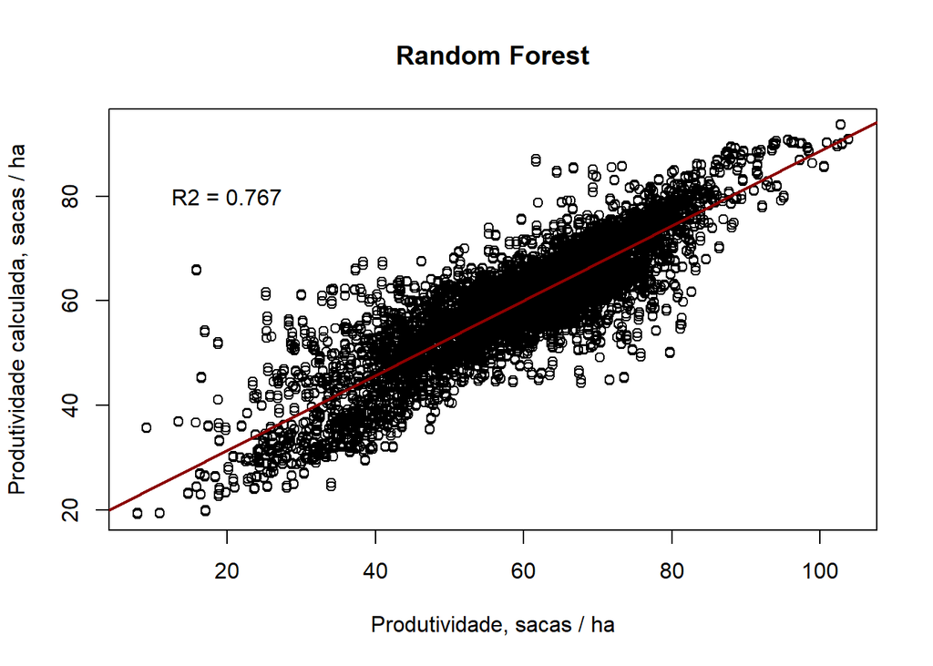

```r
library(caret)
## Not run (this may take some time to complete):
# Random Forest
# ctrl <- trainControl(method = "cv", selectionFunction = 'oneSE')
# grid <- expand.grid(.mtry = c(6, 10, 14, 18, 22), .splitrule = c("extratrees"),
#                     .min.node.size = c(1, 3, 5, 7))
# set.seed(300)
#
# m.rf <- train(productivity ~ ., data = soja, method = "ranger",
#               metric = "RMSE", trControl = ctrl, tuneGrid = grid)
#
#
# m.rf
# yhat.rf <- predict(m.rf, soja)
# plot(soja$productivity, yhat.rf)
# abline(lm(yhat.rf ~ soja$productivity), col = 'darkred', lwd = 2)
# cor(soja$productivity, yhat.rf)^2
# saveRDS(m.rf, 'soja_final.rds')
## End(Not run)

# In order to save the time required to train the RF model
# soja <- read_csv("soja_final.csv")
soja <- read_csv("soja_final.csv")
soja %<>% mutate_if(is.character, as.factor)
soja %<>% mutate_at(vars(contains("rain_")), as.factor)
soja.rf <- readRDS('soja_final.rds')
yhat.rf <- predict(soja.rf, soja)
plot(soja$productivity, yhat.rf,
     main = "Random Forest",
     xlab = "Produtividade, sacas / ha",
     ylab = "Produtividade calculada, sacas / ha")
lin.mod <- lm(yhat.rf ~ soja$productivity)
abline(lin.mod, col = 'darkred', lwd = 2)
r2.new <- summary(lin.mod)$adj.r.squared
text(20, 80, paste0("R2 = ", round(r2.new, 3)))
```

Em comparação com o modelo construído em `Soja Fase 2.Rmd`, com R<sup>2</sup> = `0.727`, este último modelo apresenta desempenho ligeiramente superior, com R<sup>2</sup> = 0.767. Não obstante a melhoria de desempenho, houve um aumento significativo da complexidade computacional do modelo final.